# State MSM Profile: **California**

### Background & Methods

In 2015-2016, researchers at Emory University partnered with colleagues at the Centers for Disease Control and Prevention (CDC) to develop methods to estimate the number of men who have sex with men (MSM) residing in each county in the United States. Using population and housing data from the [American Community Survey](https://www.census.gov/programs-surveys/acs/) and estimates from two peer-reviewed publications ([Oster et al., 2015](http://www.ncbi.nlm.nih.gov/pubmed/26115985) & [Purcell et al., 2012](http://www.ncbi.nlm.nih.gov/pubmed/23049658)), they derived an indirect estimate of MSM population sizes that took into account both the urbanicity of the county as well as its density of households with a male householder and a male same-sex partner.

The full methodology is published in the *Journal of Medical Internet Research - Public Health and Surveillance*:

> [Grey JA, Bernstein KT, Sullivan PS, Purcell DW, Chesson HW, Gift TL, Rosenberg ES. Estimating the population sizes of men who have sex with men in US states and counties using data from the American Community Survey. JMIR Public Health Surveill 2016;2(1):e14. DOI: 10.2196/publichealth.5365](http://publichealth.jmir.org/2016/1/e14/)

### Overview of MSM in California

An estimated **792,750** men who have sex with men (MSM) resided in California in 2013, representing 17.6% of the 4,503,084 MSM in the United States. Of the 13,997,953 adult men of California, 5.7% had had sex with another man in the past 5 years, which was greater than the overall percentage of adult men in the United States who were MSM (3.9%).

Most MSM in California resided in central counties of large metropolitan areas (81.3%). Including both central and fringe counties, 90.5% resided in a large metropolitan area.

##### **Percentage of MSM by urbanicity, United States and California, 2013**

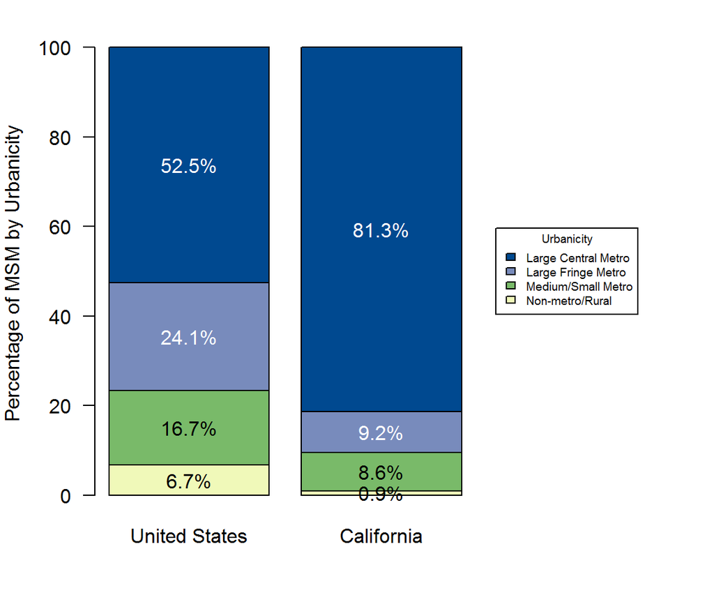

### MSM in California Counties

Among counties or county-equivalent areas in California, Los Angeles County had the largest population of MSM at 251,521, representing 31.7% of all MSM in the state. San Francisco County had the highest percentage of MSM among adult men in California at 18.5%. This was greater than the percentage for California as a whole, which was 5.7% of adult men.

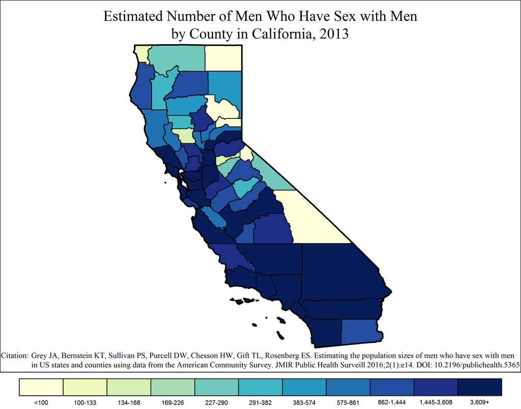

Note: Range cutpoints for the map are based on the distribution of MSM among all counties in the United States.

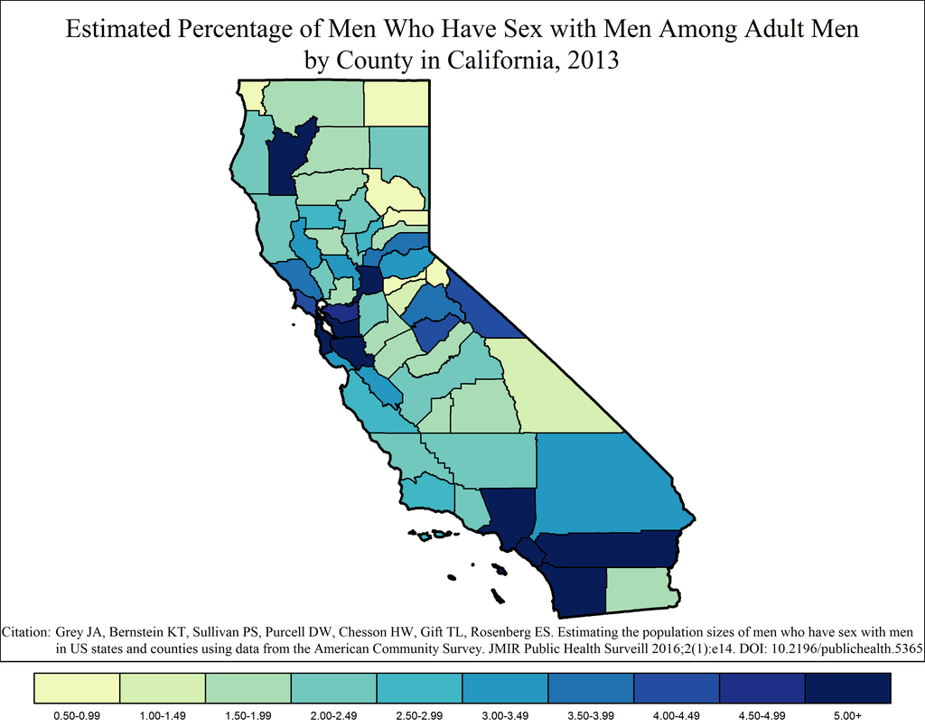

### MSM in California Metropolitan Statistical Areas

#### Los Angeles-Long Beach-Anaheim Metropolitan Statistical Area

The Los Angeles-Long Beach-Anaheim MSA had the largest metropolitan population of MSM in California at 313,711, or 39.6% of all MSM in the state. Of the 4,800,633 adult men in Los Angeles-Long Beach-Anaheim, an estimated 6.5% were MSM.

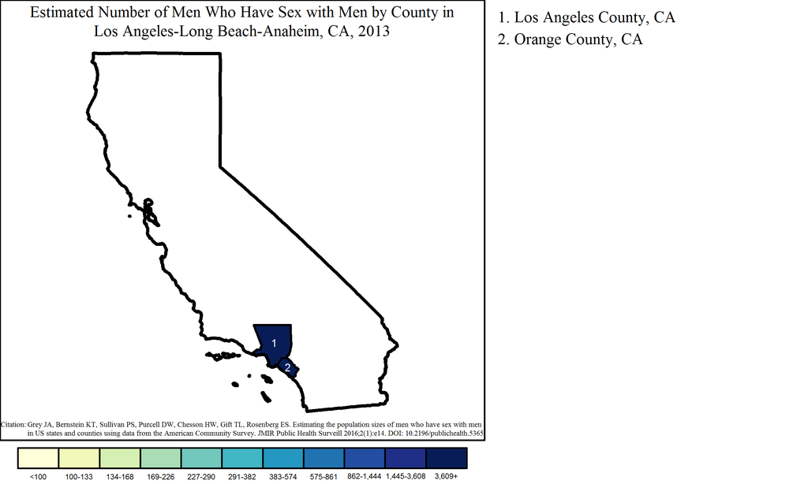

Note: Range cutpoints for the map are based on the distribution of MSM among all counties in the United States.

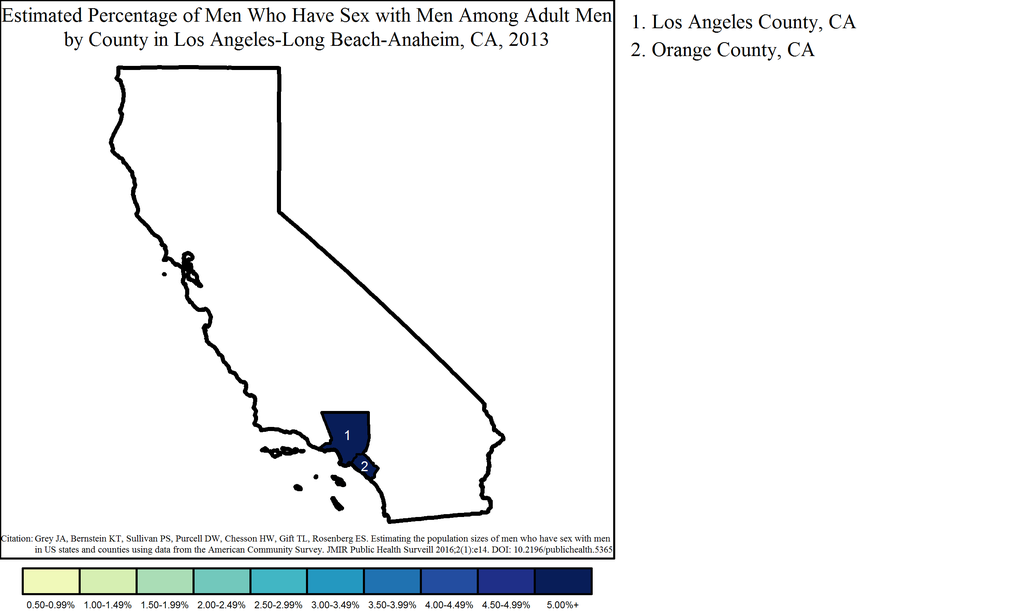

#### San Francisco-Oakland-Hayward Metropolitan Statistical Area

The San Francisco-Oakland-Hayward MSA had a population of 145,972 MSM, or 18.4% of all MSM in California. Of the 1,700,219 adult men in San Francisco-Oakland-Hayward, an estimated 8.6% were MSM.

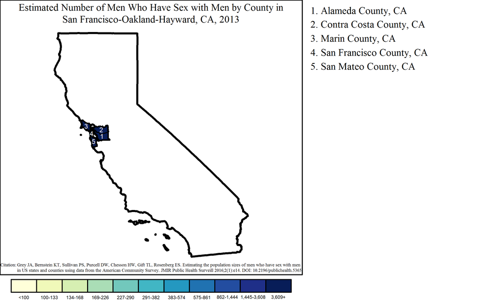

Note: Range cutpoints for the map are based on the distribution of MSM among all counties in the United States.

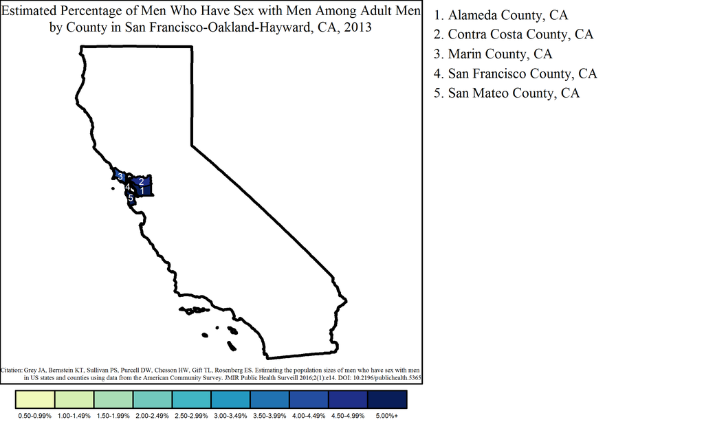

#### Riverside-San Bernardino-Ontario Metropolitan Statistical Area

The Riverside-San Bernardino-Ontario MSA had a population of 94,863 MSM, or 12.0% of all MSM in California. Of the 1,516,806 adult men in Riverside-San Bernardino-Ontario, an estimated 6.3% were MSM.

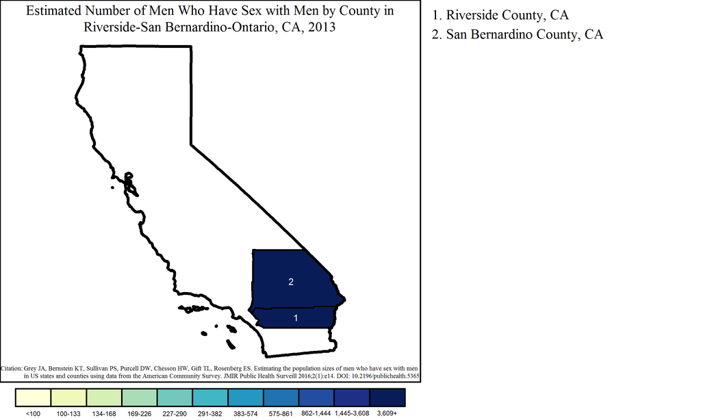

Note: Range cutpoints for the map are based on the distribution of MSM among all counties in the United States.

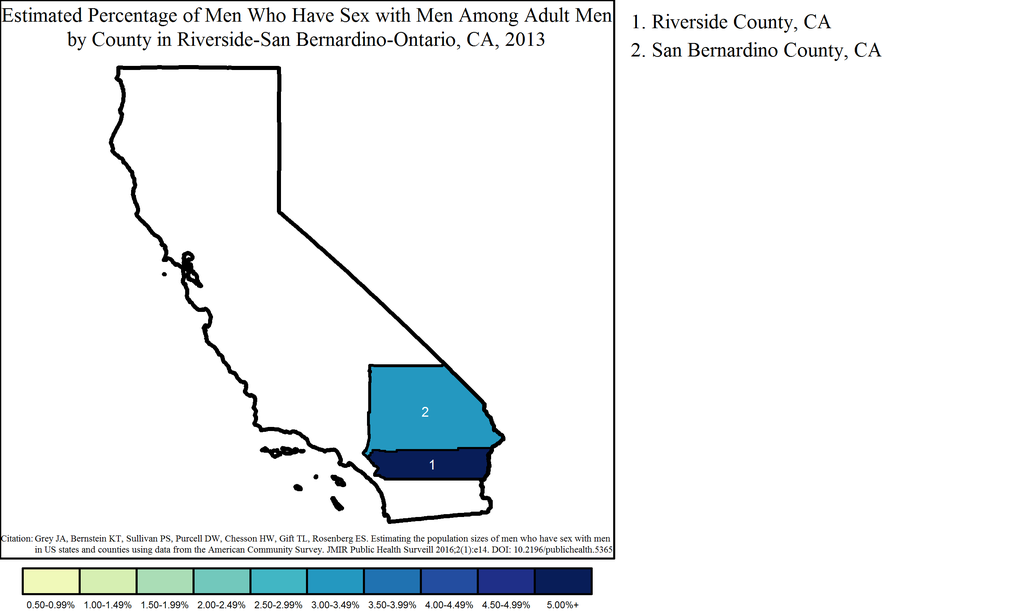

#### San Diego-Carlsbad Metropolitan Statistical Area

The San Diego-Carlsbad MSA had a population of 80,968 MSM, or 10.2% of all MSM in California. Of the 1,204,728 adult men in San Diego-Carlsbad, an estimated 6.7% were MSM.

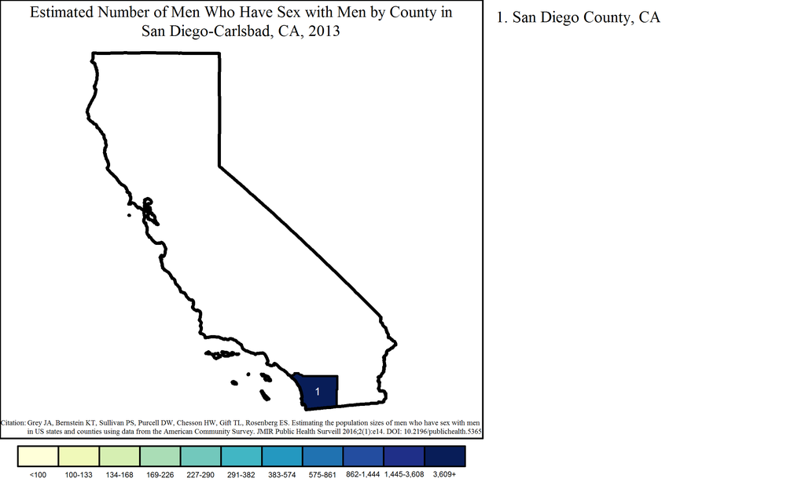

Note: Range cutpoints for the map are based on the distribution of MSM among all counties in the United States.

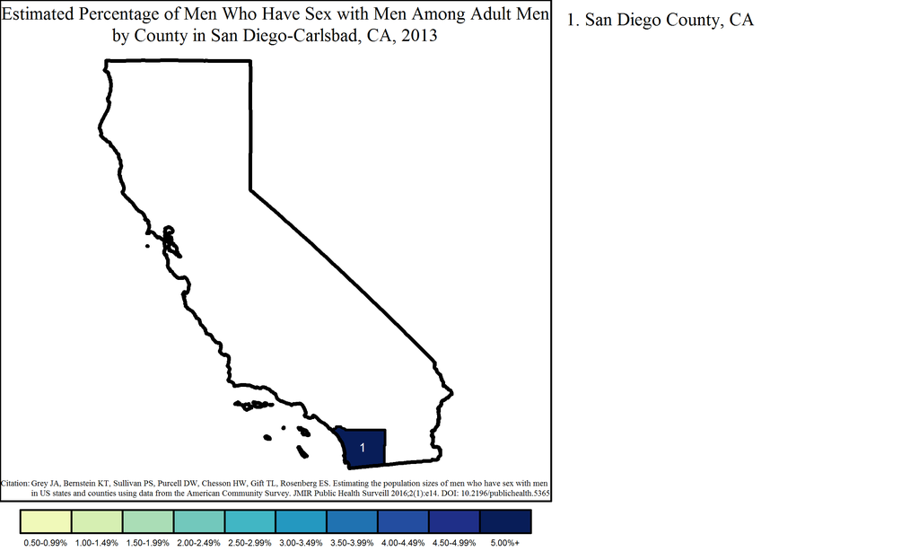

#### Sacramento–Roseville–Arden-Arcade Metropolitan Statistical Area

The Sacramento–Roseville–Arden-Arcade MSA had a population of 44,308 MSM, or 5.6% of all MSM in California. Of the 793,341 adult men in Sacramento–Roseville–Arden-Arcade, an estimated 5.6% were MSM.

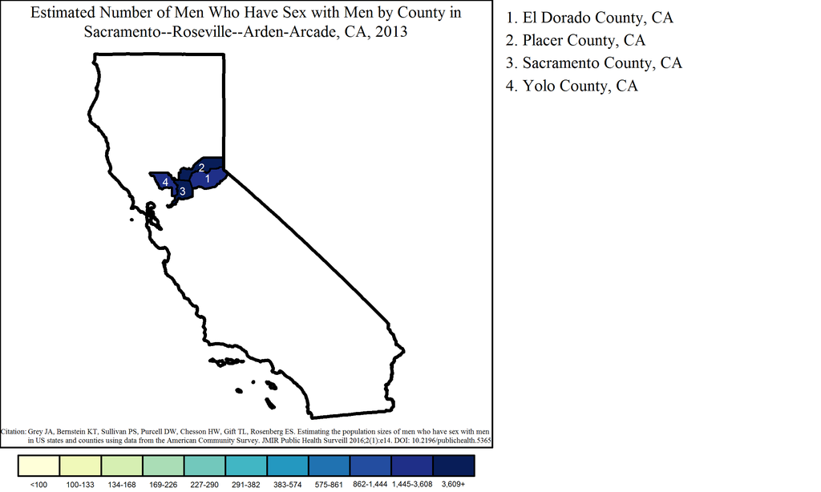

Note: Range cutpoints for the map are based on the distribution of MSM among all counties in the United States.

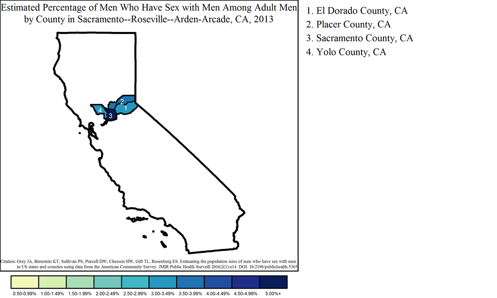

#### San Jose-Sunnyvale-Santa Clara Metropolitan Statistical Area

The San Jose-Sunnyvale-Santa Clara MSA had a population of 37,682 MSM, or 4.8% of all MSM in California. Of the 709,179 adult men in San Jose-Sunnyvale-Santa Clara, an estimated 5.3% were MSM.

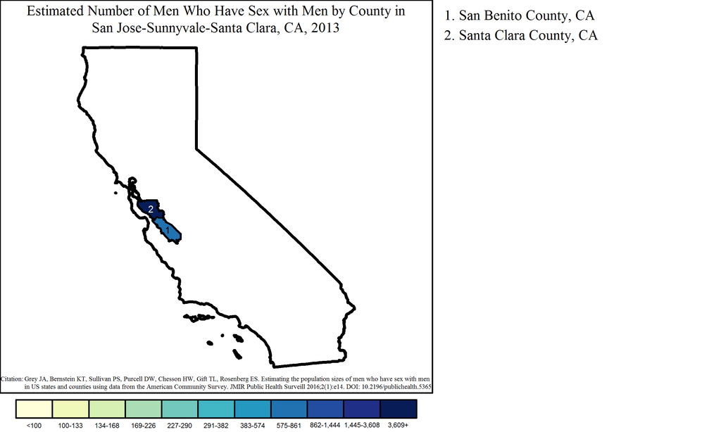

Note: Range cutpoints for the map are based on the distribution of MSM among all counties in the United States.

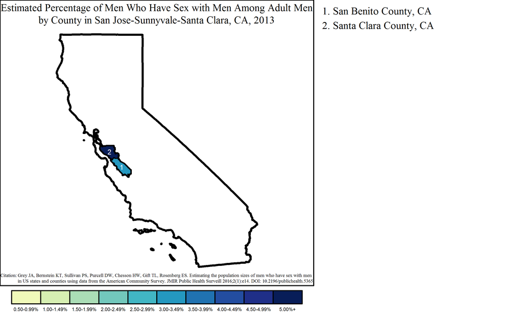

#### Fresno Metropolitan Statistical Area

The Fresno MSA had a population of 7,573 MSM, or 1.0% of all MSM in California. Of the 327,614 adult men in Fresno, an estimated 2.3% were MSM.

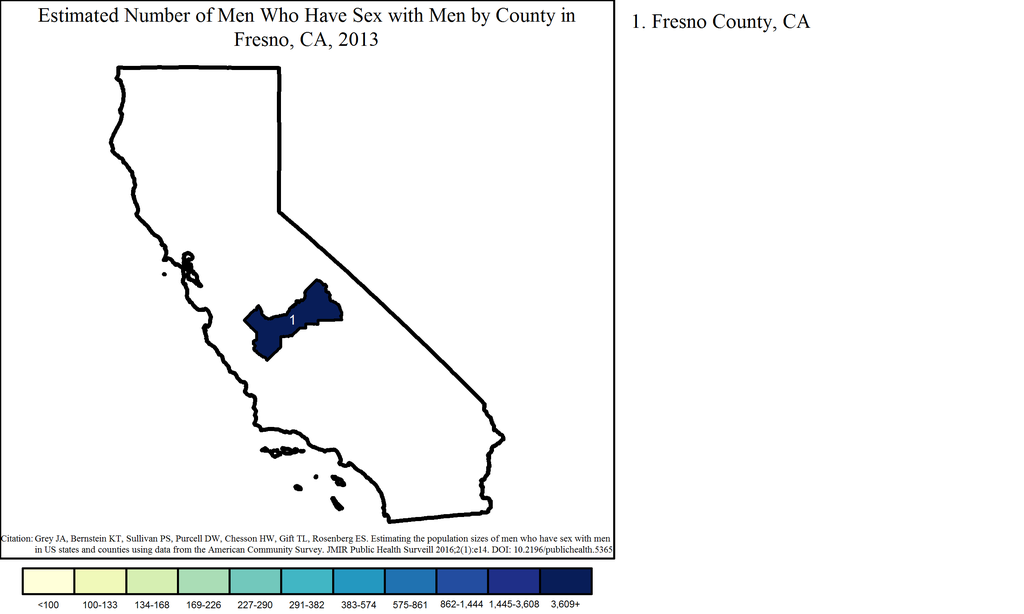

Note: Range cutpoints for the map are based on the distribution of MSM among all counties in the United States.

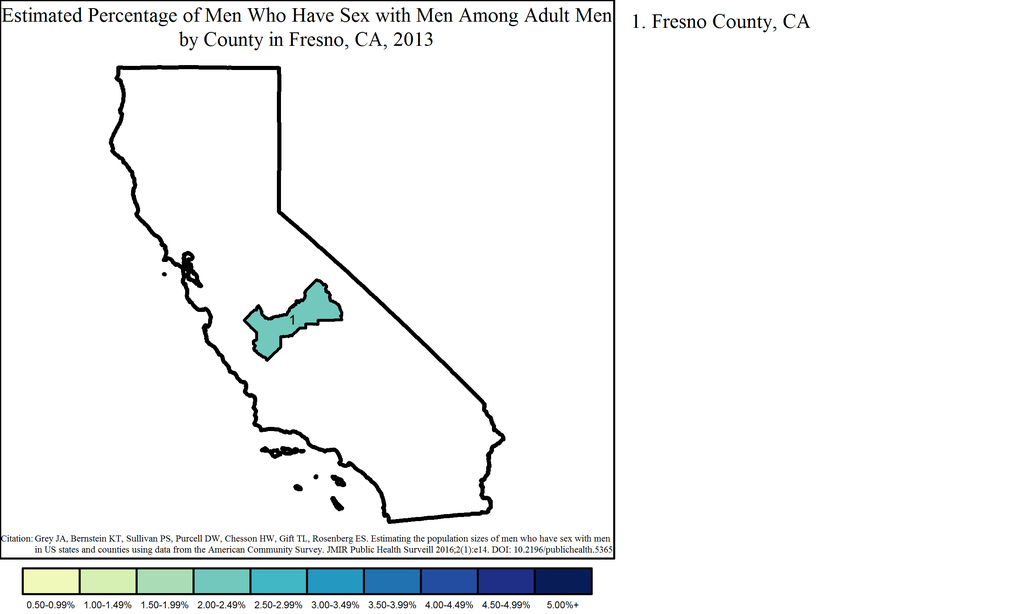

#### Oxnard-Thousand Oaks-Ventura Metropolitan Statistical Area

The Oxnard-Thousand Oaks-Ventura MSA had a population of 7,306 MSM, or 0.9% of all MSM in California. Of the 304,817 adult men in Oxnard-Thousand Oaks-Ventura, an estimated 2.4% were MSM.

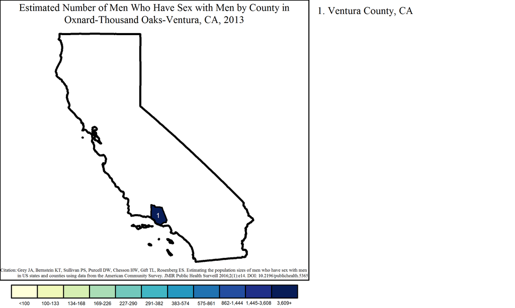

Note: Range cutpoints for the map are based on the distribution of MSM among all counties in the United States.

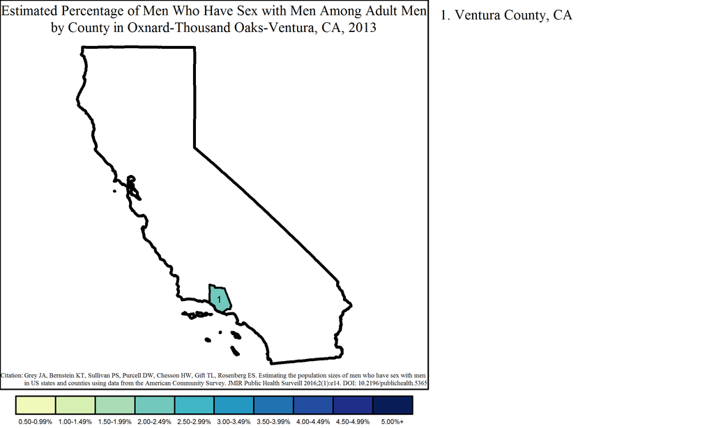

#### Santa Rosa Metropolitan Statistical Area

The Santa Rosa MSA had a population of 7,242 MSM, or 0.9% of all MSM in California. Of the 185,806 adult men in Santa Rosa, an estimated 3.9% were MSM.

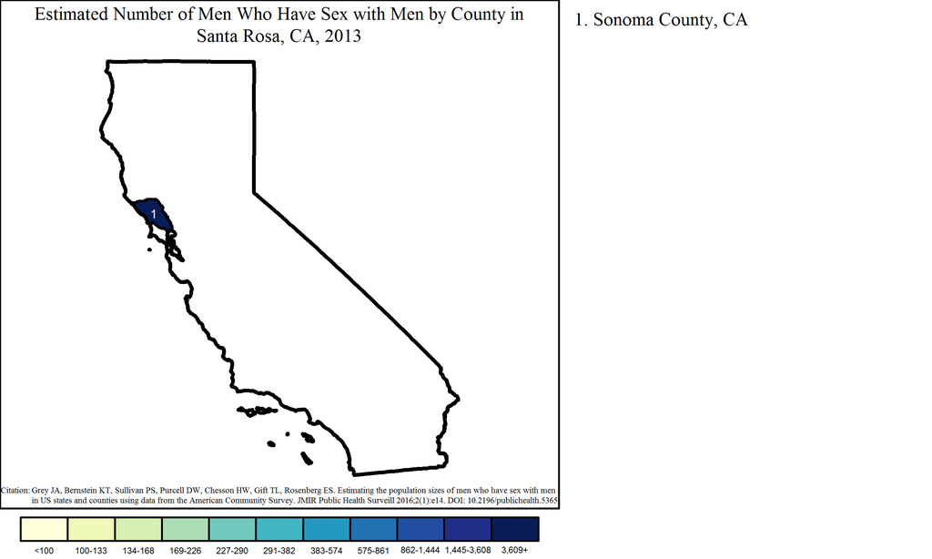

Note: Range cutpoints for the map are based on the distribution of MSM among all counties in the United States.

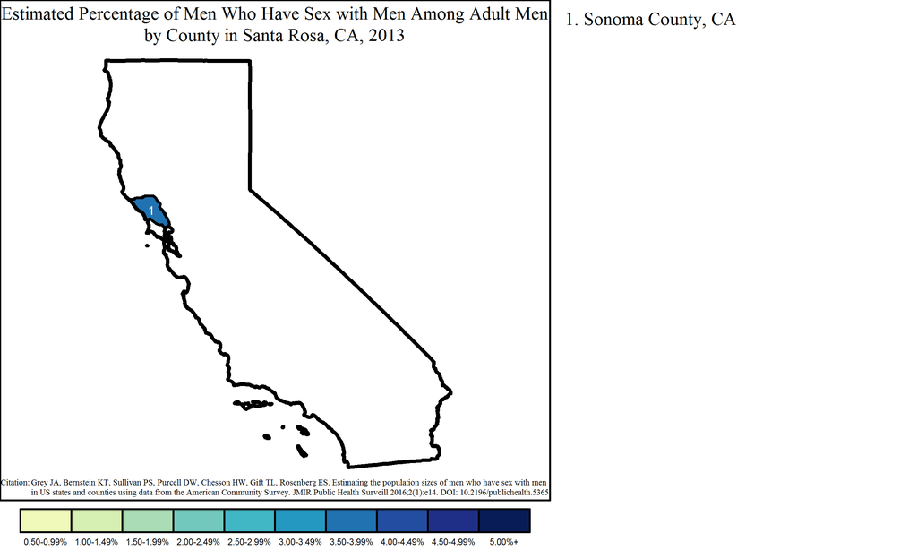

#### Bakersfield Metropolitan Statistical Area

The Bakersfield MSA had a population of 6,384 MSM, or 0.8% of all MSM in California. Of the 307,069 adult men in Bakersfield, an estimated 2.1% were MSM.

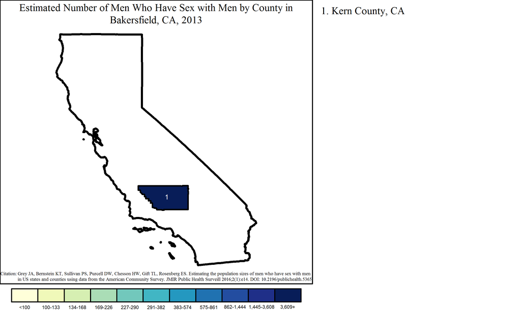

Note: Range cutpoints for the map are based on the distribution of MSM among all counties in the United States.

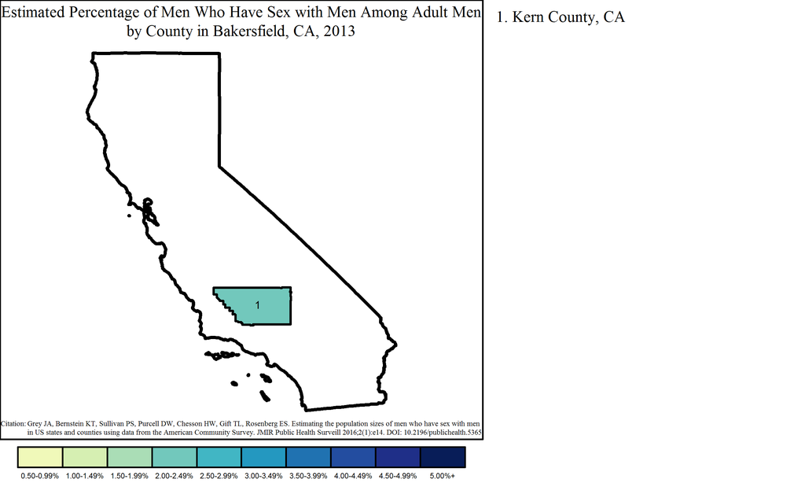

#### Stockton-Lodi Metropolitan Statistical Area

The Stockton-Lodi MSA had a population of 5,205 MSM, or 0.7% of all MSM in California. Of the 242,564 adult men in Stockton-Lodi, an estimated 2.1% were MSM.

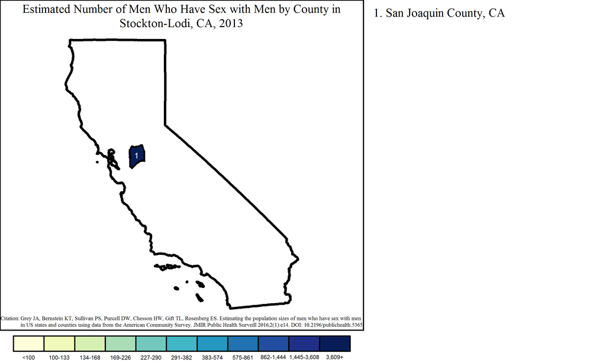

Note: Range cutpoints for the map are based on the distribution of MSM among all counties in the United States.

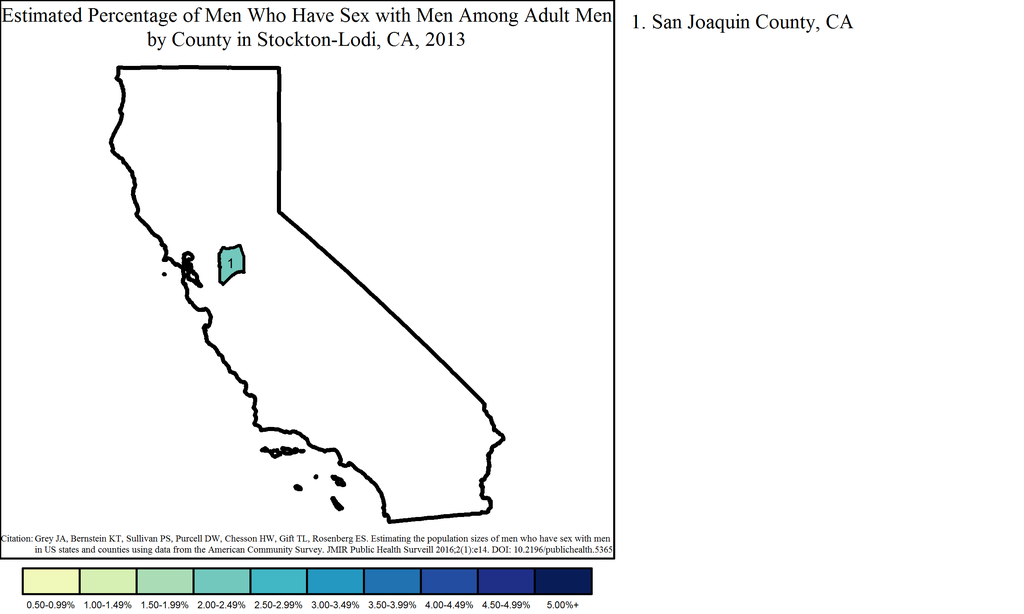

#### Salinas Metropolitan Statistical Area

The Salinas MSA had a population of 4,592 MSM, or 0.6% of all MSM in California. Of the 158,772 adult men in Salinas, an estimated 2.9% were MSM.

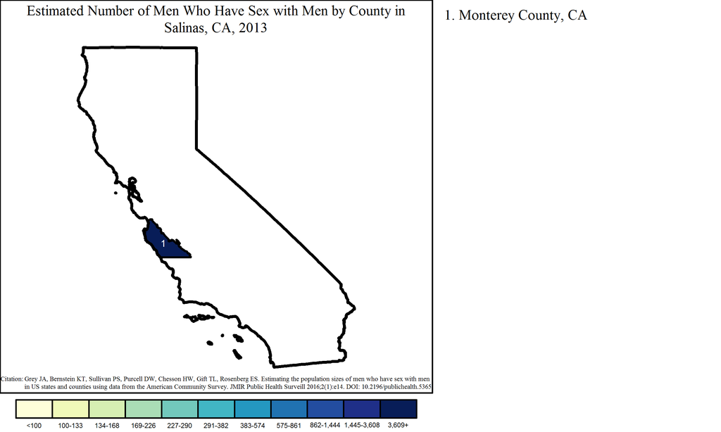

Note: Range cutpoints for the map are based on the distribution of MSM among all counties in the United States.

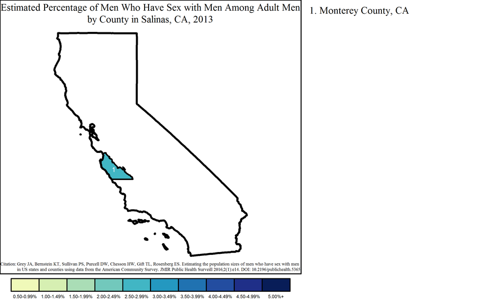

#### Santa Maria-Santa Barbara Metropolitan Statistical Area

The Santa Maria-Santa Barbara MSA had a population of 4,273 MSM, or 0.5% of all MSM in California. Of the 164,389 adult men in Santa Maria-Santa Barbara, an estimated 2.6% were MSM.

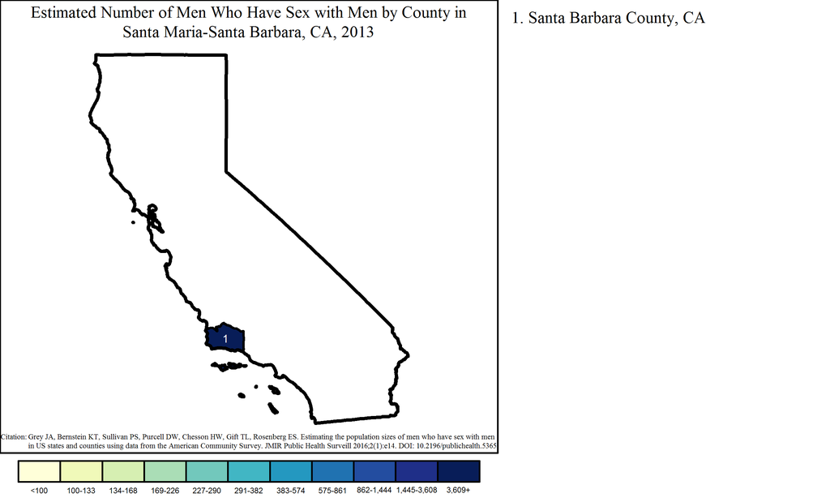

Note: Range cutpoints for the map are based on the distribution of MSM among all counties in the United States.

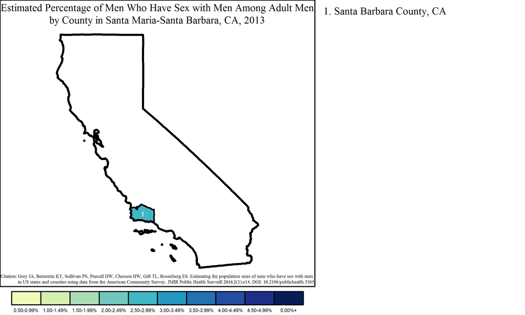

#### Santa Cruz-Watsonville Metropolitan Statistical Area

The Santa Cruz-Watsonville MSA had a population of 3,534 MSM, or 0.4% of all MSM in California. Of the 103,563 adult men in Santa Cruz-Watsonville, an estimated 3.4% were MSM.

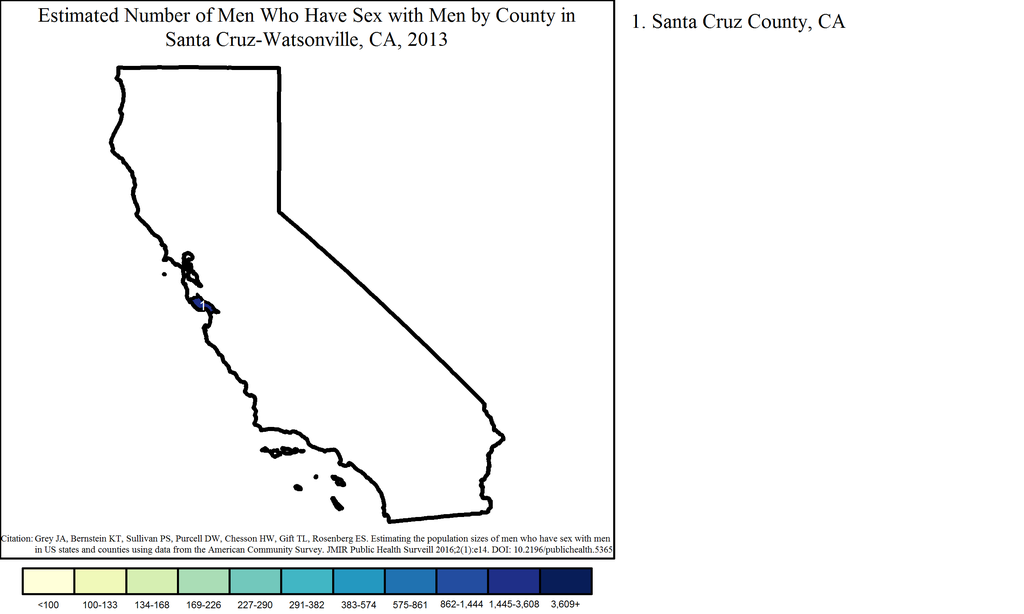

Note: Range cutpoints for the map are based on the distribution of MSM among all counties in the United States.

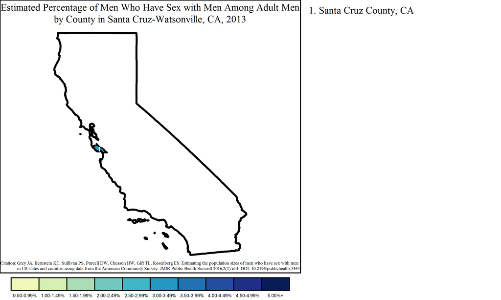